# Hypothesis test for population proportion

Date: 2017-10-04

# What it is

A hypothesis test for $p$ determines whether observed data is consistent with a hypothesized population proportion.

# When to use it

The data conditions for this hypothesis test are similar to those for the confidence interval for $p$ (a lage, fixed sample of independent binary outcomes). In addition, there should be a specific numeric value of interest (e.g., $p = 0.5$, or a CDC vaccination coverage goal) to use as the null hypothesis. If there is no specific value of interest, a confidence interval is probably more appropriate.

# How to use it

As with all hypothesis tests, begin with explicitly stating hypotheses. For this test, there are three options for the null hypothesis: $H_0:p=p_0$, $H_0: p \leq p_0$, or $H_0: p \geq p_0$, where $p_0$ is the proportion of interest. A significance level, $\alpha$, should also be chosen, usually 0.05.

In R, use the function `binom.test()`. Like with the confidence interval for $p$, we need to get the sample size and the number of successes. Suppose we want test whether the data is approximately 50% female. The null hypothesis would be $H_0: p = 0.5$, so we set the inputs `p=0.5` and `alternative='two.sided'` for the test:

This is a common way to test representativeness: if the data is not consistent with a population with 50% females, the sample is potentially biased.

```r
table(d$sex)
```

```
##
## female   male
##    267    233
```

```r
binom.test(x=267, n=500, p=0.5, alternative='two.sided', conf.level=0.95)
```

```
##
##  Exact binomial test
##
## data:  267 and 500
## number of successes = 267, number of trials = 500, p-value =
## 0.1399
## alternative hypothesis: true probability of success is not equal to 0.5
## 95 percent confidence interval:
##  0.4891844 0.5784114
## sample estimates:
## probability of success
##                  0.534
```

We see that about 53% of the sample is female, and this is within reason for a sample of this size if the true proportion is 0.5 ($p-value = 0.14$). Had the p-value been less than 0.05 (our chosen $\alpha$), we would have had evidence that the data was not consistent with a 50/50 gender split.

See also that the confidence interval covers the 0.5.

# Why it works

The hypothesis test beging by assuming $p = p_0$. If this is actually true, then the Central Limit Theorem tells us that $\hat{p}$ is normaly distributed with mean $p_0$ and variance $\frac{p_0(1-p_0)}{n}$. Then we know what values of $\hat{p}$ to expect from a sample.

Using mathematical shorthand, $\hat{p} \sim \mathcal{N}\left(p_0, \frac{p_0(1-p_0)}{n}\right)$

Since about 95% of values are within 2 standard errors of $p_0$, anything outside the range $p_0 - 2 \sqrt{\frac{p_0(1-p_0)}{n}}$ to $p_0 + 2 \sqrt{\frac{p_0(1-p_0)}{n}}$ is “unexpected” and can be taken as evidence that $p \neq p_0$. These values of $\hat{p}$ far from $p_0$ correspond exactly to values of $\hat{p}$ that will give small p-values.

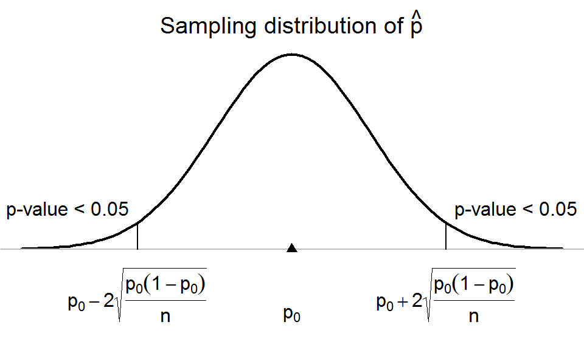